# 공간통계를 위한 데이터 사이언스

공간정보 시각화

xwMOOC

Tidyverse Korea

2019-03-11

[지도학(Cartography)](https://en.wikipedia.org/wiki/Cartography)은 지도를 제작하는 방식이다. 특정한 목적에 따라 특수한 주제 혹은 내용만을 나타내어 그린 지도를 **[주제도(Thematic Map)](https://ko.wikipedia.org/wiki/지도의_종류)** 라고 한다. 어느 시점에서의 일기 상황을 나타낸 기상도, 운전할 때 쓰이는 도로도, 항해할 때 쓰이는 해도, 통계값을 지도에 그려 넣은 통계 지도 등이 좋은 사례다.

지리정보를 표현하기 위해서는 다음과 같은 기본 요소가 필요하다.

1. `.shp`, `.geojson`, `.gpkg` 확장자를 갖는 지도파일
2. 지리 위치를 나타내는 위도 경도
3. 해당 위도경도 지점, 선, 다각형 지역에 표현할 속성정보(attributes)

# 1 지리정보 파일(SHP)

대한민국 센서스용 행정구역경계(시군구) 자료는 [통계지리정보서비스](http://sgis.kostat.go.kr/contents/shortcut/shortcut_05.jsp) 사이트에서 자료신청을 하면 얻을 수 있다. 그리고, 제공되는 자세한 형식에 대한 정보는 *자료신청* → *자료제공 목록*을 참조한다. 혹은, [Encaion](https://goo.gl/KyHR46) 구글 드라이브에서 직접 다운로드 받을 수도 있다. 통계청으로 신청하면 승인까지 수일이 소요되며 행정처리일 기준으로 처리되며 다운로드 가능한 기간도 1주일이다.

- [GADM](http://www.gadm.org/) 데이터베이스에서 *Country*에서 **South Korea*을 선택하고,* File Format*에서* Shapefile*을 선택하여 다운로드한다.
- [DIVA-GIS](http://www.diva-gis.org/gdata) 사이트에서도 자유로이 한국을 포함한 여러국가 지도를 다운로드 받을 수 있다.
- [통계지역경계](http://sgis.kostat.go.kr/contents/shortcut/shortcut_05.jsp)
- [Global Administrative Areas](http://www.gadm.org/country)
- [팀 포퐁 GitHub](https://github.com/southkorea/southkorea-maps)

```r
FILEMAP = {
    'shp': [('skorea-shp.zip','http://biogeo.ucdavis.edu/data/gadm2/shp/KOR_adm.zip')],
    'kmz': [('skorea.kmz','http://biogeo.ucdavis.edu/data/gadm2/kmz/KOR_adm0.kmz'),
            ('skorea-provinces.kmz','http://biogeo.ucdavis.edu/data/gadm2/kmz/KOR_adm1.kmz'),
            ('skorea-municipalities.kmz','http://biogeo.ucdavis.edu/data/gadm2/kmz/KOR_adm2.kmz')],
    'r'  : [('skorea.RData','http://biogeo.ucdavis.edu/data/gadm2/R/KOR_adm0.RData'),
            ('skorea-provinces.RData','http://biogeo.ucdavis.edu/data/gadm2/R/KOR_adm1.RData'),
            ('skorea-municipalities.RData','http://biogeo.ucdavis.edu/data/gadm2/R/KOR_adm2.RData')]
```

# 2 대한민국 - 지리정보

대한민국 지도에 관한 일반정보의 경도범위는 124 – 132, 위도범위는 33 – 43 이다.

[Degrees Minutes Seconds to Decimal Degrees](https://www.latlong.net/degrees-minutes-seconds-to-decimal-degrees)

우리 나라 지도 좌표계는 준거 타원체로 Bessel 타원체를 사용하며 (장반경: 6378397.155m, 단반경: 6356078.96284m, 평편율 : 200.15)이며, 경위도는 지리좌표를 사용하고 있다. 평면직각 좌표계의 경우 국가기본도는 TM좌표를, 군사용 지도는 UTM좌표를 사용하고 있다.

1910년 만들어진 국내 영토의 좌표가 110년만인 2020년, 일본식에서 국제표준으로 바뀐다고 2015년 국토교통부가 발표를 하였다. [우리땅 좌표 전환](https://news.joins.com/article/17310993) 기사를 통해서 대략적인 내용을 확인할 수 있다. 우리땅 좌표, 지적도의 좌표만 남쪽 315m, 동쪽 185m씩 이동되고, 우리나라 모든 공간정보는 국제표준으로 바뀌된다고 합니다. [^3]

- 일제시대 좌표: bessel타원체
- ITRF 좌표계: 세계측지계
- GPS: WGS80타원체

# 3 대한민국지도 - `rworldmap`

지도가 구해졌으면 범위를 한정하기 위해 극점(extreme point) 정보를 알아내는 것이 중요하다. [남한 극단정보](https://en.wikipedia.org/wiki/Extreme_points_of_South_Korea) 위키피디아에서 확인한 극점정보를 사용하여 남한지도를 그려본다.

## 3.1 세계지도

`rworldmap` 팩키지를 사용해서 `getMap()` 함수로 세계지도 데이터를 가져온다. `str(korea_spdf, max.level = 2)` 명령어를 통해서 “SpatialPolygonsDataFrame”임을 확인할 수 있다. “SpatialPolygonsDataFrame” 객체는 지리정보(공간 다각형, Spatial Polygons)와 데이터프레임이 결합된 데이터다.

```r
#install.packages(rworldmap)
library(rworldmap)
library(ggmap)

korea_spdf <- rworldmap::getMap(resolution = "high")

str(korea_spdf, max.level = 2)
```

```
Formal class 'SpatialPolygonsDataFrame' [package "sp"] with 5 slots
  ..@ data       :'data.frame': 244 obs. of  49 variables:
  ..@ polygons   :List of 244
  ..@ plotOrder  : int [1:244] 12 184 39 227 42 33 16 88 114 9 ...
  ..@ bbox       : num [1:2, 1:2] -180 -90 180 83.6
  .. ..- attr(*, "dimnames")=List of 2
  ..@ proj4string:Formal class 'CRS' [package "sp"] with 1 slot
```

## 3.2 주소정보 → 위경도

영문으로 구성된 대한민국 주소정보를 `ggmap` 팩키지 `geocode()` 함수에 던져 위도와 경도 정보를 가져와서 이를 `plot()` 함수로 시각화한다.

```r
south_korea_limits <- geocode(c(
  "Daegang-ri, Hyeonnae-myeon, County of Goseong, Gangwon",
  "Marado, Daejeong-eup, Seogwipo, Jeju",
  "Dokdo-ri,Ulleung-eup, County of Ulleung, North Gyeongsang",
  "Baengnyeongdo, Baengnyeong-myeon,    County of Ongjin, Incheon")
)

south_korea_limits
```

```
# A tibble: 4 x 2
    lon   lat
  <dbl> <dbl>
1  128.  38.6
2  126.  33.1
3  132.  37.2
4  125.  38.0
```

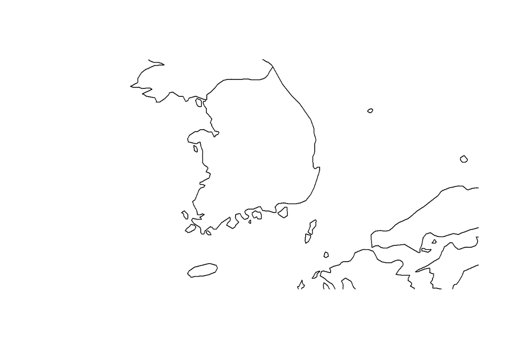

```r
plot(korea_spdf,
     xlim = range(south_korea_limits$lon),
     ylim = range(south_korea_limits$lat),
     asp = 1
)
```

[남한 극단정보](https://en.wikipedia.org/wiki/Extreme_points_of_South_Korea) 중 섬을 제외한 본토를 기준으로 지리정보를 시각화하면 다음과 같다. 동일한 방식으로 섬을 제외한 본토를 기준으로 위도경도 정보를 받아오고 이를 바탕으로 시각화한다.

```r
south_korea_mainland_limits <- geocode(c(
  "Daegang-ri, Hyeonnae-myeon, County of Goseong, Gangwon",
  "Songho-ri, Songji-myeon, Haenam, South Jeolla",
  "Guryongpo-eup, Pohang, North Gyeongsang",
  "Mohang-ri, Sowon-myeon, Taean, Chungcheong")
)

south_korea_mainland_limits
```

```
FALSE # A tibble: 4 x 2
FALSE     lon   lat
FALSE   <dbl> <dbl>
FALSE 1  128.  38.6
FALSE 2  127.  34.3
FALSE 3  130.  36.0
FALSE 4  126.  36.8
```

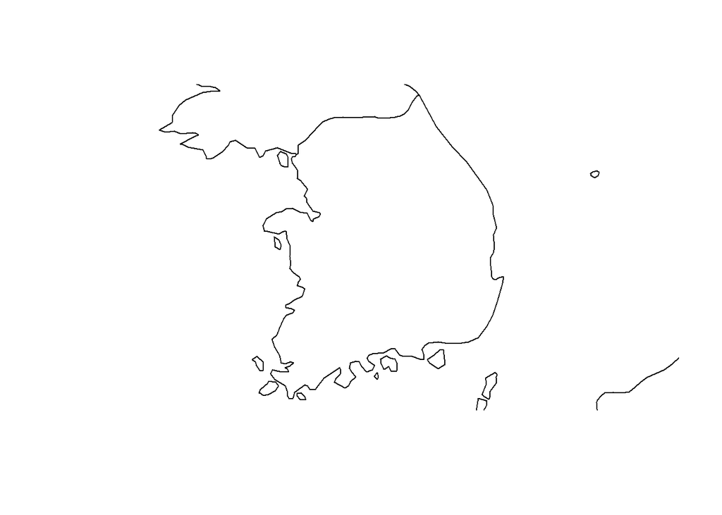

```r
plot(korea_spdf,
     xlim = range(south_korea_mainland_limits$lon),
     ylim = range(south_korea_mainland_limits$lat),
     asp = 1
)
```

# 4 참고자료

## 4.1 웹사이트

- [Thematic Cartography and Geovisualization](http://www.amazon.com/Thematic-Cartography-Geovisualization-3rd-Edition/dp/0132298341)
- [Web Cartography: Map Design for Interactive and Mobile Devices](https://www.crcpress.com/Web-Cartography-Map-Design-for-Interactive-and-Mobile-Devices/Muehlenhaus/9781439876220)
- [R Development Translation Team (Korean)](http://www.openstatistics.net/)

## 4.2 R 언어 참고 웹사이트

- [spatial.ly](http://spatial.ly/r/)
- [Spatial data in R: Using R as a GIS](https://pakillo.github.io/R-GIS-tutorial/)
- [Introduction to Spatial Data and ggplot2](http://rpubs.com/RobinLovelace/intro-spatial)
- [Spatial analysis in R: 랭커스터 대학](http://www.maths.lancs.ac.uk/~rowlings/Teaching/-%20Sheffield2013/index.html)
- [Notes on Spatial Data Operations in R](https://dl.dropboxusercontent.com/u/9577903/-%20broomspatial.pdf)
- [Making maps with R](http://www.molecularecologist.com/2012/09/making-maps-with-r/)

## 4.3 지리정보처리 툴체인

- 오픈 GIS 소프트웨어
  - [System for Automated Geoscientific Analyses (SAGA GIS)](https://en.wikipedia.org/wiki/SAGA_GIS)
  - [Geographic Resources Analysis Support System (GRASS GIS)](https://en.wikipedia.org/wiki/GRASS_GIS)
- [TileMill](https://www.mapbox.com/tilemill/)
- KML 마크업 언어
  - [Keyhole Markup Language, KML](https://en.wikipedia.org/wiki/Keyhole_Markup_Language)

## 4.4 지리정보 시각화 사례

- 미국 대선(2012) [뉴욕타임즈 President Map](http://elections.nytimes.com/2012/results/president)
- 미국 빈곤율 정보 시각화 [The Topography of Poverty in the United States](http://www.cdc.gov/pcd/issues/2007/oct/07_0091.htm)
- [http://indiemapper.com/](http://indiemapper.com/app/learnmore.php?l=choropleth)
[^1]: [대한민국의 위도와 경도를 알고 싶어요](http://tip.daum.net/question/3092152)
[^2]: [데일리전북(2009년 08월 16일), 우리나라의 중심점은 어디일까?](http://www.dailyjeonbuk.com/news/articleView.html?idxno=54514)
[^3]: [중앙일보 (2015.03.09 15:18), “우리땅 좌표 전환, 110년 만에… 대한민국 국민이라면 반드시 알아야 할 우리의 역사”](https://news.joins.com/article/17310993)